# Git 1st Time

Author

Ed123 Pal

## 1 Introduction

This tutorial instructs on how to use a workflow for a typical but simple Git use case. This includes making limited use of GitHub.

## 2 Learning Objectives

After completing this tutorial, you should be able to:

1. Create a private repository (repo) on GitHub.
2. Clone the repo to your computer, i.e. create a local repo.
3. Add a tiny demo R script to the repo.
4. Stage the changes.
5. Create a commit.
6. Push the commit to the remote repo, i.e. the GitHub from where you cloned the repo.

## 3 GitHub Repo

### 3.1 GitHub log on

Log on to the GitHub account you created in the GitHub Get Started tutorial.

### 3.2 Create repo

After you log on to GitHub, click New to start the process of creating a repo.

[figure not shown]

Name the repo “Git_1st_time”.

Enter “Used in Git tutorial” as the Description.

Click the private radio button.

[figure not shown]

Check the Add a README file check box.

Select the R .gitignore template from the drop down menu.

Click Create repository.

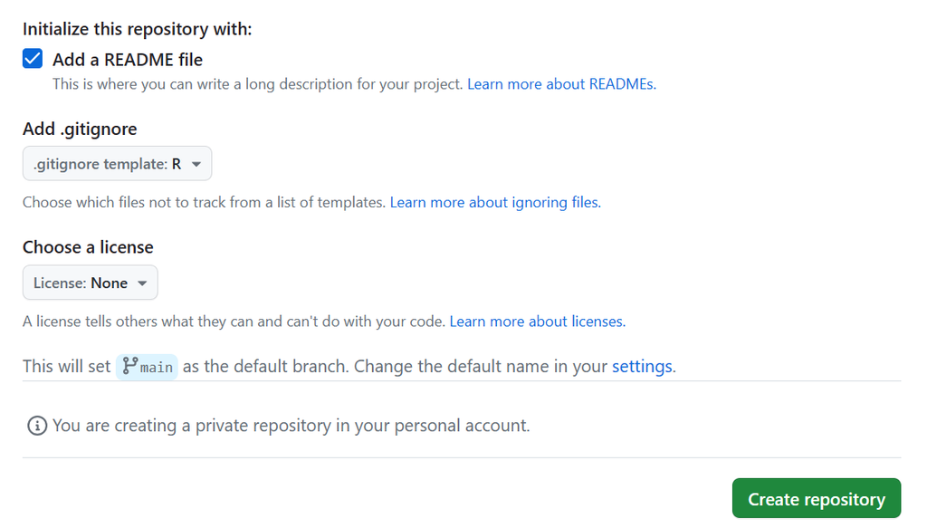

### 3.3 Review repo

See that GitHub has created the first commit named “Initial commit”.

The repo contains .gitignore and a README.md files.

[figure not shown]

### 3.4 Repo URL

Click code to see the URL for the repo.

Click the copy icon to copy the URL to your clipboard. Open Notepad++ and paste the URL and save the file to your computer (it will be used later when cloning the remote repo to a local repo).

[figure not shown]

## 4 See GitHub Repo

The next few screenshots demonstrate the importance of designating a repo to be private unless there is a good reason for it to be public.

The scenarios below show a random person attempting to see the Git_1st_time repo on GitHub. These attempts will fail because the repo is private. At the end, there is a scenario where the owner of the skip123paschall GitHub account logs on and then (as expected) can see the Git_1st_time repo project.

### 4.1 Browse GitHub account

Using a browser, enter the URL for the GitHub account where the Git_1st_time repo was created.

Here’s the URL: https://github.com/skip123paschall

The first screenshot below shows what’s seen after entering the URL. Notice the screenshot shows only six repositories, but there is a “7” next to the Repositories link at the top of the page. Click on the Repositories link to see all seven repositories (see second screenshot below).

[figure not shown]

[figure not shown]

### 4.2 Public vs private

The Git_1st_time repo is not seen in the list of repositories shown in the screenshot above because the repo is private.

The seven repositories listed in the screenshot above are the repositories that are public on the skip123paschall account.

Browse GitHub repo

The screenshot above was the result of browsing to the GitHub account for the GitHub account named skip123paschall. As seen above, only the public repositories could be seen.

The screenshot just below shows what happens if you browse to a specific GitHub repo for GitHub user skip123paschall. This screenshot shows an attempt to browse to Git_1st_time, which is private. Since it is private, GitHub returns a 404, i.e. page not found. This means that a random person on the internet cannot access a private GitHub repo even if they know the name of the repo.

[figure not shown]

In contrast to what’s seen above, a random person on the internet can browse to a specific GitHub repo that is public. The screenshot below shows browsing to repo SageBistroSurvey that is public.

**Note**

GitHub repositories that are public can be accessed (and cloned) by random people via the internet. This is why it’s a best practice to make GitHub repositories private unless you have a reason for making it them public.

[figure not shown]

### 4.3 All repositories

To emphasize the points made above, the screenshot below shows what’s seen then logging into the skip123paschall GitHub account. Note the number “13” next to the Repositories link. Subtracting 7 from 13 means there are 6 private repositories on this GitHub account.

As expected, after clicking on the Repositories link, one of the repositories shown in the screenshot below is the Git_1st_time repo.

[figure not shown]

## 5 Clone Repo

### 5.1 Clone 1

**Note**

This first attempt to clone the repo from the remote (i.e. GitHub) to a local repo (i.e. on your computer’s disk drive) will fail. See below for the reason.

Open a Command Prompt window and enter the git clone command as shown below.

The highlighted portion of the command is the name of the repo.

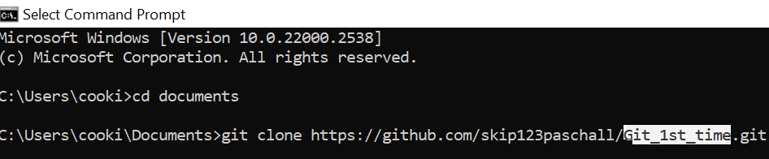

Since the repo is private, the clone process prompts to have you enter the GitHub credentials for the skip123paschall GitHub account. DO NOT ENTER THE CREDENTIALS. Instead click on the X to close this window.

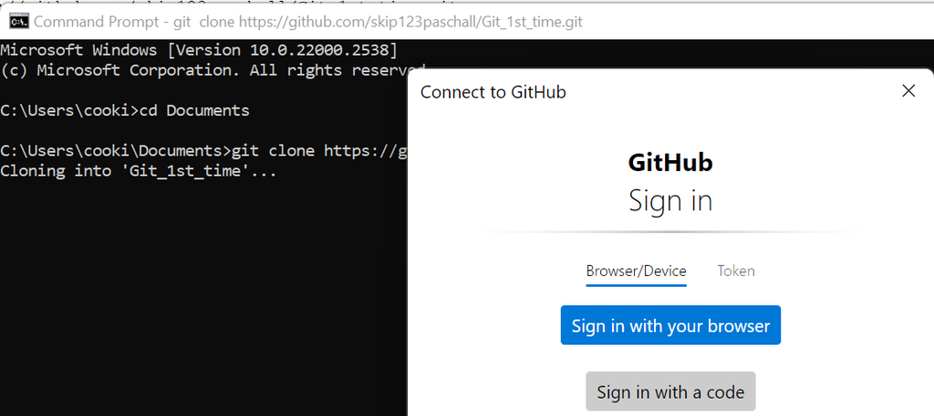

**Note**

Enter credentials as prompted in the preceding screenshot will result in your GitHub credentials being stored in the Windows Credential Manager (WCM). Using WCM can be appropriate in some circumstance, but it can introduce complications that are avoided in this tutorial. Instead, later in this tutorial, you’ll be instructed to take a different, simpler, approach to clone a private GitHub repo where you are the owner of the GitHub account.

After you click X to close the dialogue window shown above, you’ll see a command line prompt asking for your GitHub user name. Again, DO NOT ENTER your GitHub user name. Instead close the Command Prompt window.

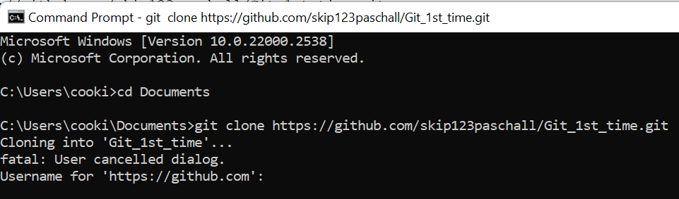

### 5.2 Clone 2

**Note**

This attempt to clone repo Git_1st_time will work because a PAT will be put into the URL for the remote (i.e. GitHub) repo.

Open another Command Prompt window and re-enter the git clone command, but this time the URL will contain the Personal Access Token (PAT) that you created when your GitHub account was created in the GitHub Get Started tutorial.

The PAT is highlighted in the screenshot below. Notice the @ sign needs to be added before the github.com part.

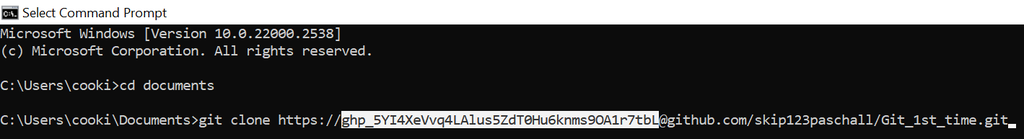

**Note**

Be aware the git clone command shown above is simple is that it allows authentication to GitHub because the PAT is passed directly in the URL. There is a security risk that the PAT could be intercepted by someone who is “sniffing” your internet transmission. Practically speaking, the risk is low especially in a training/tutorial situation. In a a professional / production work environment, your security team will require and advise on GitHub authentication techniques that are more secure.

The git clone command shown in the preceding screenshot will succeed. The screenshot below shows some information regarding the successful clone.

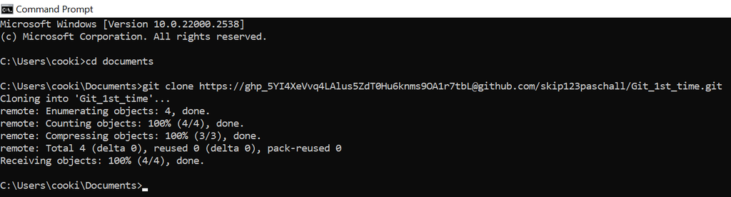

The clone process created a folder named “Git_1st_time” within the Documents folder.

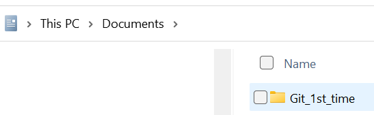

The Git_1st_time folder contains the .gitignore and README files that were created by GitHub when the repo was created using GitHub.

The .gitignore file is a hidden file. The .gitignore file identifies files and folders within the project that will not be tracked by Git. Therefore, when you do a push to send data to GitHub these ignored files and folders will not be sent.

A hidden .git folder was also created. This .git folder actually holds the Git local repo.

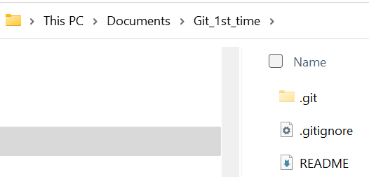

One of the files in the .git folder is the config file. Specifically, this file is referred to as the local Git config file and items in this file will override items in the Global config file, which overrides items in the System config file.

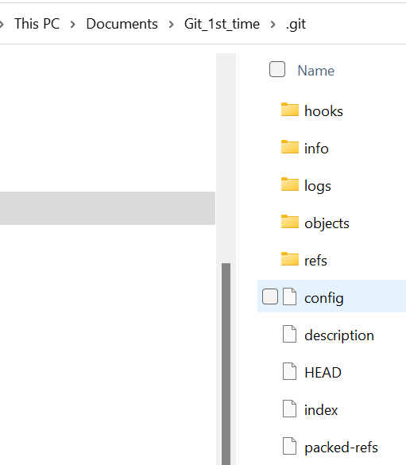

Using Notepad++, examine the contents of the Git local config file.

The git clone command created an entry in the config file to identify the URL of the remote repo associated with the local Git repo. Note how the PAT is also part of the URL. Having the PAT in the URL will make it easy to push future commits to GitHub because no additional authentication is needed. However, keep in mind this local Git config file must be handled in a secure manner so your GitHub PAT is not accessed by another person.

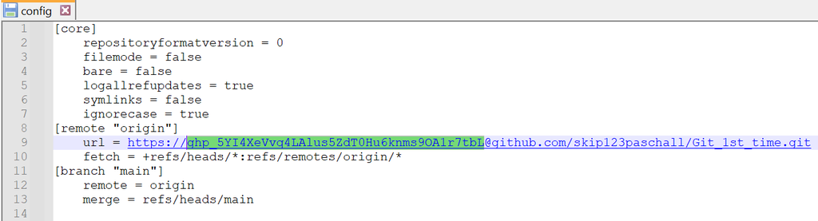

## 6 Update Push Local

**Note**

The learning objective for this section is ultimately to make and push a small change to your remote repo. Along the way, you’ll be instructed on several aspects of working with a local repo.

### 6.1 Run git status

Using File Explorer, see the project (i.e. local repo) still just contains the files and folder that were created by GitHub when the repo was created on GitHub.

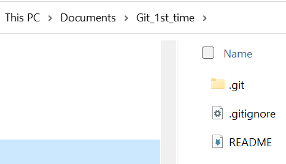

Open a Command Prompt window and run the git status command.

The “On branch main” line indicates that git status is reporting on the status of the branch named “main”.

**Note**

The repo currently contains a single branch, which is named “main”. This tutorial does not cover the topic of creating and working with branches in a Git repo. In this tutorial, we’ll only be working with the main branch.

The “Your branch is up to date with ‘origin/main’.” indicates that your remote (GitHub) repo is in synch with your local (on your PC) repo. Another way of describing what’s meant by this line is to say you have not created any Git commits that have not been pushed to the remote repo.

The “nothing to commit, working tree clean” line means you have not made any changes to any of the files and folders in the repo that have not yet been added to the local Git staging area.

**Note**

This concept of the Git staging area will be discussed shortly in this tutorial. The staging area is also sometimes called the index.

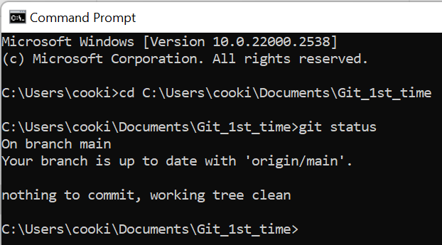

### 6.2 R script file

Add a script named code_challenge.r to the root of the project folder.

Below you can see the code_challenge.r script file listed in the Files tab.

[figure not shown]

### 6.3 Run git status

**Note**

The following paragraph uses some Git terms and concepts that have not yet been introduced, but don’t worry because they will be covered soon in this tutorial. I’m using these terms just below to initially acquaint you with their use.

Run the git status again. This time, Git reports there is a file that is not being tracked (i.e. status says it is “Untracked”). What this means is that Git has detected the file has been added to the working directory but it has not yet been staged. Shortly in this tutorial, a git add command will be used to stage the code_challenge.r file.

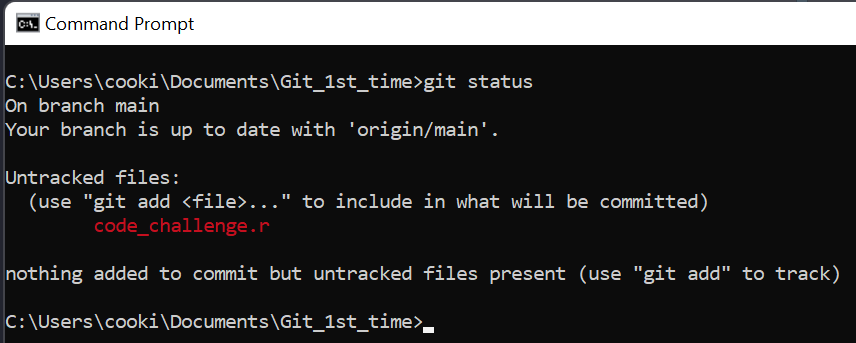

### 6.4 Test R script

Run/test the script to verify it’s working.

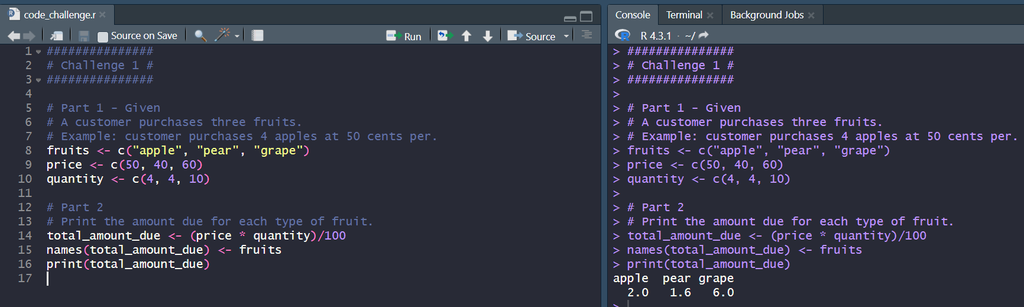

### 6.5 Stage R script

**Note**

Before staging the R script, this tutorial needs to provide information about several key Git concepts. So, below are several narratives that introduce these key concepts.

**Note**

Git workflow

A key part of the Git workflow involves the progression of files through this workflow:

Working Directory => Staging Area (Index) => Commit

An important aspect of a Git repository (repo) is that it’s the accumulation of all commits performed on the repo.

**Note**

Working Directory - general concepts

Good news: you can esily see the files and folders that are in working directory.

What you see in the RStudio Files tab panel or when looking at your project using File Explorer is what Git calls the “Working Directory”. To you, these are the files and folders that make up the current version of your project. You do all the typical things with the files and folder in the working directory just as if you were not using Git with your project, i.e. change existing files, add files and delete files.

But, since your project is “under Git version control” then Git monitors the files and folders in your project’s working directory. When you do a git status, Git is able to report about changes to the working directory. At this point in the tutorial you’ve recently added a new file (code_challenge.r) to the working directory. Git has detected this new file. However, git status says the R script is an “Untracked file”. One way to envision the situation is to say that code_challeng.r is in the project, but not yet “officially” part of the Git repo.

The way to make Git “officially” recognize code_challenge.r as being part of the repo is to run git add, which puts the file into the Git staging area (also called the Git index).

**Note**

Staging Area (Index)

Bad news: “Staging Area” and “Index” pretty much mean the same thing in Git. Having two names for the same thing often causes confusion for new Git users. Mostly in this tutorial, I’ll say staging area instead of index. One reason for my preference of say “staging area” is that most people will often say something like, “the code has been tested, so now let’s stage the code file(s)”.

Bad news: after doing git add, you must run git status or git ls-files to see the files and folders that are in the staging area.

Use the git add . command to add the code_challenge.r file to the Git staging area (a.k.a. index). The code below uses a . after add. Using the period is like a wildcard. The period instructs Git to add all new files and folders to the staging area. Typically, it’s appropriate to just use the period. However, if you want to stage a single file then you could code “git add code_challenge.r”. In the case of this tutorial it would be the same as coding “git add .”.

Once code_challenge.r has been staged then Git will now be tracking any future changes to this file. Another way of stating this is to say that “code_challenge.r” is now under version control.

The screenshot below also shows the result of again running git status after the git add. This time the status is reporting the code_challenge.r file is ready to be committed. When files are in the staging area then Git suggests the next step is to run git commit (this will be discussed next).

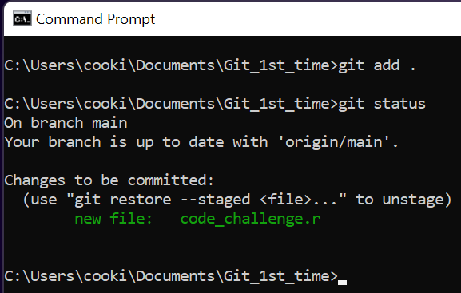

### 6.6 Create commit

Run the git commit command in order to create a commit that contains all the files and folders that are in the Git staging area. Once a commit is created the staging area is cleared, i.e. no longer contains any files or folders.

**Note**

Again, the way people discuss using Git can vary and cause confusion.

People sometimes so “do a commit”, “commit the changes”, or “perform a commit”. They all mean the same thing. Regardless, what’s actually happening is that a commit is being created.

Commits are an essential part of using Git. One way of envisioning a commit is to think of it as a snapshot of a set of file and folder changes that you’ve made to your repo at a given point of time. If in the future you’ve made additional changes to a file that was parat of an earlier commit then you can use Git commands to retrieve the state of that file as it was at the point of the earlier commit. The Git term “revert” is associated with for this “traveling back in time” to obtain an earlier version of a file that was included in a commit.

For this tutorial, there is just one file in the staging area so the commit consists of just a single file, i.e. code_challenge.r.

**Note**

Remove file from staging area before commit.

If you put a file into the staging area (i.e. by doing a “git add”) then that action can easily be undone. What that means is that you can remove a single item or all items from the staging area by doing a git restore. Remember though, git restore must be done before doing git commit.

Reverting a commit

As mentioned earlier, there are ways to reverse (the term is revert) a commit but it’s more complicated and will be discussed in a later tutorial. For now, just make sure that before creating a commit that you’re happy with the files and folders that are in the staging area.

Since a commit is a permanent item in a repo and since you may want to go back and retrieve a file that was in a commit done sometime in the (recent or far) past then it’s important to have a description of the changes that were part of a commit. For this reason, Git requires that a message be created when you do a commit. It can be a short message or a long one. The screenshot below shows using the -m flag to created a short message. If the -m flag is omitted then when the commit command is executed a text editor will open where you can create a long commit message. When you area searching through a list of past commits, you can see your commit messages. This could help you to identify a specific commit if you’re seeking to revert back to an earlier version of a specific file.

The screenshot below also shows the results of git status after the commit has been created.

The “On branch main” line indicates that your working directory reflects what’s on the branch of your repo that is named “main”. You have not created any other branches as part of this tutorial.

The line that says, “Your branch is ahead of ‘origin/main’ by 1 commit.” uses the word “origin”. By default Git uses “origin” as a shorthand way of referring to the URL for the remote (GitHub in this case) repository that corresponds to your local Git repo (that’s on your computer’s hard drive). The “is ahead of” part of the message indicates you’ve created a commit on your local repo and that commit is not yet in the remote repo. The message finally suggests that you do “git push” to publish your local commits”. Doing git push is a way to synchronize your local and remote Git repositories. Doing git push is discussed next.

Finally the line “nothing to commit, working tree clean” is saying the staging area is empty and also there are not any un-staged changes in the working directory.

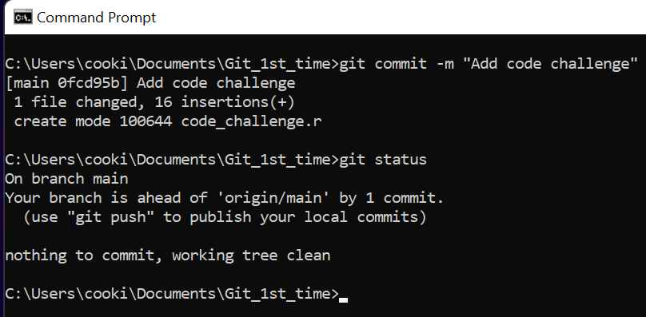

### 6.7 Do push

You can create a single commit and then push that commit to your remote repo. You can also create multiple commits (for example three commits) and then push all three commits to the remote repo in conjunction with a single push.

At this point in this tutorial, just one commit has been created and it will now be pushed to the remote repo.

The push command in the screenshot below uses origin, which (recall) is shorthand for the URL of the remote repo. See the project-level config file for details of the origin.

The push command seen below also uses main, which (recall) is the name of the Git branch that contains the commit being pushed to the remote repo. For this tutorial, we’ve only worked with a single branch that is named “main”.

The screenshot below also shows the results of git status after the push has been performed.

The line stating, “Your branch is up to date with ‘origin/main’ is saying your local and remote repositories are now synchronized.

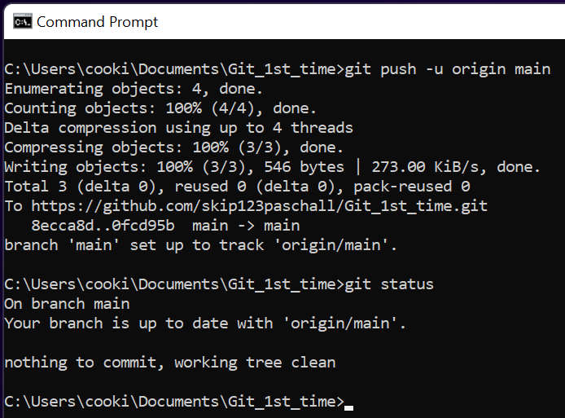

## 7 GitHub Repo

### 7.1 GitHub log in

Log in to your GitHub account and select the Git_1st_time repo.

The screenshot below shows the same files that are in your local repo working directory along with the most recent commit message associated with when that file was committed.

The screenshot shows there is just one branch in the repo and the name of the branch being seen is “main”. It also shows there have been 2 commits made on the main branch.

[figure not shown]

### 7.2 View commits

Click on the 2 commits link seen in the preceding screenshot.

What’s seen is the screenshot below is a lost of the commits mode on the main branch of the repo.

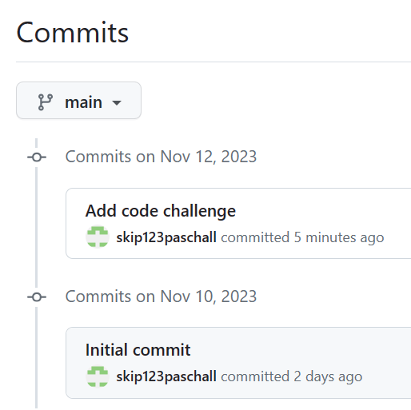

Hover the mouse the commit message, e.g. Add code challenge and it will turn into a link. Click on the link and it will then show a screen displaying the contents of each file in the commit.

[figure not shown]

## 8 Collaborate

**Note**

Using Git and GitHub to facilitate collaboration is beyond the scope of this tutorial. However, this brief section is included to provide a peak at what’s possible and as a preview of information to be covered in a future tutorial.

### 8.1 With yourself

A prime example of using Git and GitHub to collaborate with yourself would be a situation where you’ve been developing a solution on your office desktop computer but you want to continue working on it on your laptop computer while you away attending a conference.

Since, at this point in this tutorial, your local and remote repositories are synchronized then you can simply perform a git clone on your laptop. Doing so will create a local repo on your laptop that is the exact copy of the repo that is on your desktop copy.

While your at the conference, you can working on the local repo on your laptop and as needed stage and commit changes. You will need to eventually push commits created on your laptop to the remote repo.

When you return to your office, you can perform a git pull on your desktop computer to merge the changes (now on the remote repo) into your local repo. When that’s done then you can resume working on your project using the local Git repo that’s on your desktop computer.

## 9 With others

If a time comes when you want to share your project with others and possibly have them also work on your project then the remote repo located on GitHub will again the key resource that will enable collaboration.

Collaborating with others introduces many other considerations (and to some degree complexity) in using Git and GitHub. But both are well-designed to support collaboration. In future tutorials, you can learn how to convert a project from private to public so other can access it. Additional Git and GitHub features that support collaboration include (1) forking a repo that is on GitHub, (2) creating a pull request and (3) merging changes.

## 10 Wrap Up

### 10.1 Congratulations!

You’ve completed this tutorial and should no be able to explain fundamental Git and GitHub concepts. Likewise you should be able to apply this concepts to implement a basic workflow that results in a project being put under Git version control and having the result repositories be synchronized on both local and remote repositories.

### 10.2 What’s next?

This tutorial is intended to equip you with basics Git and GitHub skills so that you can start using these tools and so that you have a foundation for learning more about them.

It’s important that you soon gain familiarity with how to revert commits so that you can “time travel” to retrieve earlier versions of your project.

Collaboration is an important reason for using version control so learning to apply concepts introduced in the preceding Collaborate section is another important next step.